# A1_Group_7_Assignment_6

A1_Group_7

10/15/2021

```r
library(tidyr)
library(ggplot2)
library(ggmap)
library(leaflet)
library(leaflet.extras)
library(tidyverse)
library(lubridate)
library(scales)
require(gridExtra)
data <- read.csv("Lesson 8/Assignment 6/flights.csv")
airlines <- read.csv("Lesson 8/Assignment 6/airlines.csv")
airports <- read.csv("Lesson 8/Assignment 6/airports.csv")
```

### Data Cleaning

```r
data$date <- paste(data$YEAR,data$MONTH,data$DAY,sep = "-")

data$SCHEDULED_DEPARTURE1 <- substr(as.POSIXct(sprintf("%04.0f", data$SCHEDULED_DEPARTURE), format='%H%M'), 12, 19)
data$SCHEDULED_DEPARTURE_TIME <- strptime(paste(data$date,data$SCHEDULED_DEPARTURE1),format='%Y-%m-%d %H:%M:%S')

data$DEPARTURE_TIME1 <- substr(as.POSIXct(sprintf("%04.0f", data$DEPARTURE_TIME), format='%H%M'), 12, 19)
data$ACTUAL_DEPARTURE_TIME <- strptime(paste(data$date,data$DEPARTURE_TIME1),format='%Y-%m-%d %H:%M:%S')

data$WHEELS_OFF1 <- substr(as.POSIXct(sprintf("%04.0f", data$WHEELS_OFF), format='%H%M'), 12, 19)
data$WHEELS_OFF_TIME <- strptime(paste(data$date,data$WHEELS_OFF1),format='%Y-%m-%d %H:%M:%S')

data$WHEELS_ON1 <- substr(as.POSIXct(sprintf("%04.0f", data$WHEELS_ON), format='%H%M'), 12, 19)
data$WHEELS_ON_TIME <-  strptime(paste(data$date,data$WHEELS_ON1),format='%Y-%m-%d %H:%M:%S')

data$SCHEDULED_ARRIVAL1 <- substr(as.POSIXct(sprintf("%04.0f", data$SCHEDULED_ARRIVAL), format='%H%M'), 12, 19)
data$SCHEDULED_ARRIVAL_TIME <- strptime(paste(data$date,data$SCHEDULED_ARRIVAL1),format='%Y-%m-%d %H:%M:%S')

data$ARRIVAL_TIME1 <- substr(as.POSIXct(sprintf("%04.0f", data$ARRIVAL_TIME), format='%H%M'), 12, 19)
data$ACTUAL_ARRIVAL_TIME <- strptime(paste(data$date,data$ARRIVAL_TIME1),format='%Y-%m-%d %H:%M:%S')

flights <- data

flights_cleaned <- select(flights,-c("YEAR","MONTH","DAY","SCHEDULED_DEPARTURE","DEPARTURE_TIME","WHEELS_OFF","WHEELS_ON","SCHEDULED_ARRIVAL","ARRIVAL_TIME","SCHEDULED_DEPARTURE1","DEPARTURE_TIME1","WHEELS_OFF1","WHEELS_ON1","SCHEDULED_ARRIVAL1","ARRIVAL_TIME1"))

index <- flights_cleaned$SCHEDULED_DEPARTURE_TIME>flights_cleaned$SCHEDULED_ARRIVAL_TIME & !is.na(flights_cleaned$SCHEDULED_ARRIVAL_TIME)
flights_cleaned$SCHEDULED_ARRIVAL_TIME[index] <- flights_cleaned$SCHEDULED_ARRIVAL_TIME[index]+lubridate::days(1)

index <- flights_cleaned$ACTUAL_DEPARTURE_TIME>flights_cleaned$WHEELS_OFF_TIME & !is.na(flights_cleaned$WHEELS_OFF_TIME)
flights_cleaned$WHEELS_OFF_TIME[index] <- flights_cleaned$WHEELS_OFF_TIME[index]+lubridate::days(1)

index <- flights_cleaned$WHEELS_OFF_TIME>flights_cleaned$WHEELS_ON_TIME & !is.na(flights_cleaned$WHEELS_ON_TIME)
flights_cleaned$WHEELS_ON_TIME[index] <- flights_cleaned$WHEELS_ON_TIME[index]+lubridate::days(1)

index <- flights_cleaned$WHEELS_ON_TIME>flights_cleaned$ACTUAL_ARRIVAL_TIME & !is.na(flights_cleaned$ACTUAL_ARRIVAL_TIME)
flights_cleaned$ACTUAL_ARRIVAL_TIME[index] <- flights_cleaned$ACTUAL_ARRIVAL_TIME[index]+lubridate::days(1)

head(flights_cleaned,5)
```

```
##   DAY_OF_WEEK AIRLINE FLIGHT_NUMBER TAIL_NUMBER ORIGIN_AIRPORT
## 1           4      AS            98      N407AS            ANC
## 2           4      DL          2336      N958DN            DEN
## 3           4      DL          2440      N651DL            SEA
## 4           4      AS           108      N309AS            ANC
## 5           4      AA          2392      N3HRAA            DEN
##   DESTINATION_AIRPORT DEPARTURE_DELAY TAXI_OUT SCHEDULED_TIME ELAPSED_TIME
## 1                 SEA             -11       21            205          194
## 2                 ATL              -6       12            173          149
## 3                 MSP              -1       28            189          198
## 4                 SEA              -4       17            204          194
## 5                 MIA              21       12            227          208
##   AIR_TIME DISTANCE TAXI_IN ARRIVAL_DELAY DIVERTED CANCELLED
## 1      169     1448       4           -22        0         0
## 2      133     1199       4           -30        0         0
```

[output cut: 27 more lines]

### Which airline is the best?

```r
flights_cleaned$delays <- ifelse(flights_cleaned$AIR_SYSTEM_DELAY > 0,1, ifelse(flights_cleaned$LATE_AIRCRAFT_DELAY > 0,1,ifelse(flights_cleaned$AIRLINE_DELAY > 0,1,0)))
flights_cleaned[is.na(flights_cleaned$delays),]$delays <- 0

avrg_delay <- flights_cleaned %>% group_by(AIRLINE) %>%
  filter(ARRIVAL_DELAY>0) %>%
  summarise(avrg_delay=mean(ARRIVAL_DELAY)) %>%
  arrange(desc(.[,2]))

delays <- flights_cleaned %>% group_by(AIRLINE) %>% summarise(delayed=sum(delays))
total_flights <- flights_cleaned %>%  group_by(AIRLINE) %>% summarise(count=n())
merged <- merge(delays,total_flights,on="AIRLINE")

airline_stats <- merge(merged,avrg_delay,by="AIRLINE")
airline_stats$delay_perc <- (airline_stats$delayed/airline_stats$count)*100

head(airline_stats,5)
```

```
##   AIRLINE delayed count avrg_delay delay_perc
## 1      AA   12731 72579   34.38732   17.54089
## 2      AS    2279 17236   22.68561   13.22233
## 3      B6    6019 27031   37.81492   22.26703
## 4      DL   11532 87375   31.14004   13.19828
## 5      EV   10874 57499   35.90833   18.91163
```

### 1. Average Delay Time (Negative delay time not included)

```r
avrg_delay_plot <- airline_stats %>%  ggplot(aes(x=reorder(AIRLINE, avrg_delay),y=avrg_delay,fill=AIRLINE)) +
  geom_bar(stat="identity",width=0.7) +
  labs(y="Average Delay (Minutes)") +
  theme(axis.title.x=element_blank(),legend.position = "none")
```

### 2. Delay Percentage (Only including air system delay, airline delay and late aircraft delay)

```r
delay_perc_plot <- airline_stats %>% ggplot(aes(x=reorder(AIRLINE, delay_perc),y=delay_perc, fill=AIRLINE)) +
  geom_bar(stat="identity",width=0.7) +
  labs(y="Percentage of Delayed Flights") +
  theme(axis.title.x=element_blank(),legend.position = "none")
```

### 3. Total Flights

```r
options(scipen = 10000)

total_flights_plot <- airline_stats %>% ggplot(aes(x = reorder(AIRLINE, -count), y = count, fill = AIRLINE)) +
  geom_bar(stat="identity",width=0.7) +
  labs(y="Total Flights") +
  scale_y_continuous(labels = comma) +
  theme(axis.title.x=element_blank(),legend.position = "none", axis.text.y = element_text(angle = 90,hjust=0.5))
```

### 1, 2, 3 Combined

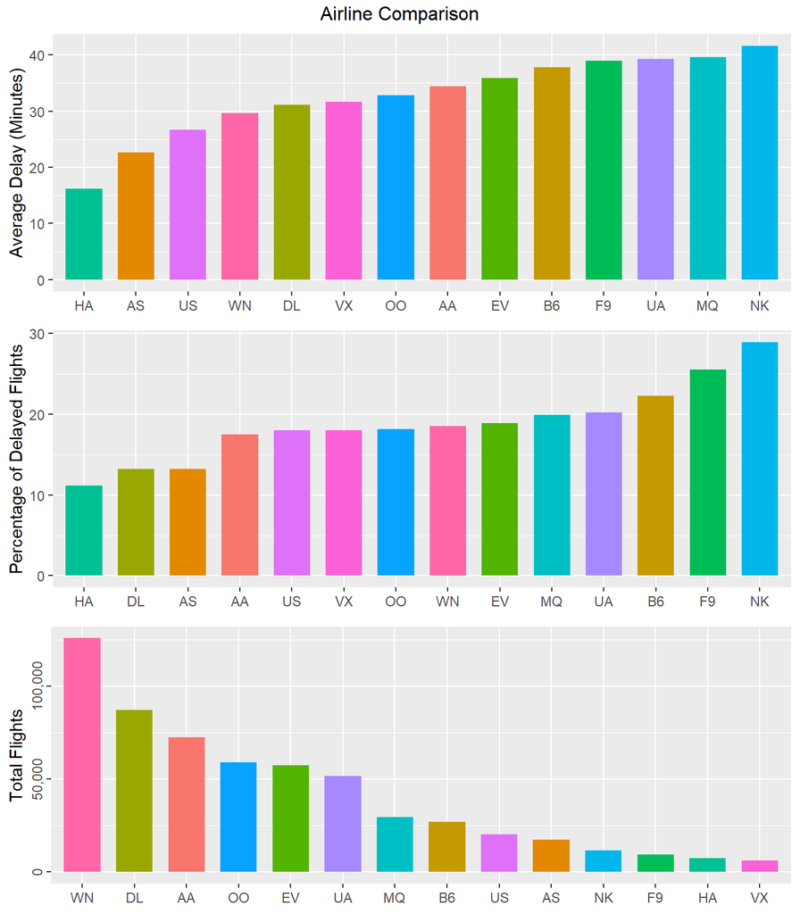

```r
grid.arrange(avrg_delay_plot,delay_perc_plot,total_flights_plot,top="Airline Comparison")
```

### Chart 1, 2 and 3 visualised as a scatter plot

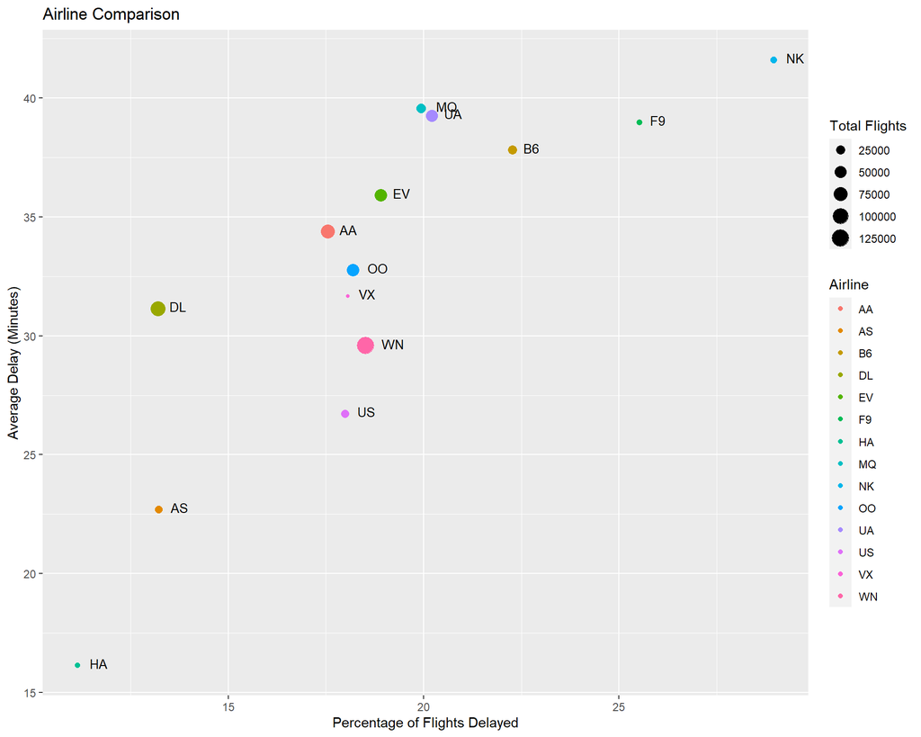

```r
airline_stats %>% ggplot(aes(x=delay_perc,y=avrg_delay,size=count)) +
  geom_point(aes(color=AIRLINE)) +
  geom_text(aes(label=AIRLINE,hjust=-0.7,vjust=0.3),size=3.5) +
  labs(title="Airline Comparison",x="Percentage of Flights Delayed",y="Average Delay (Minutes)",size="Total Flights",color="Airline")
```

From the visualisations, we can see that based on the average delay and percentage of flights delayed, HA, AS and US perform the best. However, they have very few total flights. Comparatively, airlines such as WN, DL, OO and AA have a significantly greater number of flights yet still manage to do relatively well.

### Unpleasant Index: Which airline should be avoided?

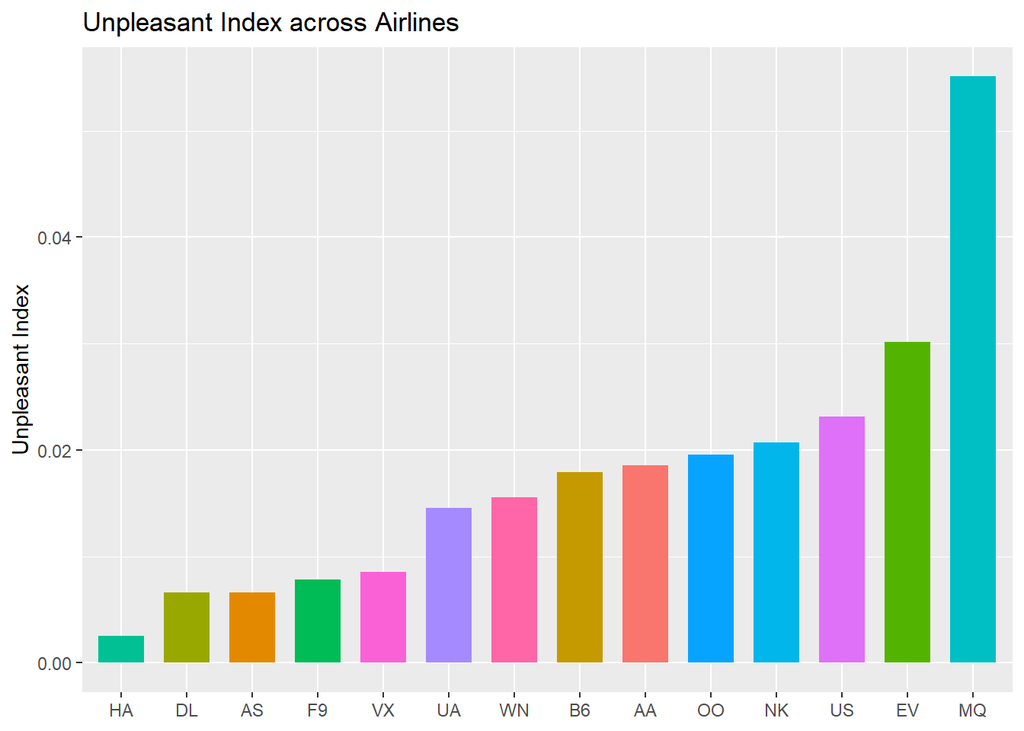

```r
unpleasant <- 0
airlines <- unique(flights_cleaned$AIRLINE)

# for a long/short haul flight, what is the maximum delay before it is considered unpleasant
# assume that it is unpleasant if a flight gets cancelled or diverted
# arrival refers to the maximum duration of delay before it is considered unpleasant (after accounting for departure delay)
# "a" represents the selected airline
unpleasant.index <- function(long,short,arrival,a)
{
  flights.a <- flights_cleaned %>% filter(AIRLINE==airlines[a])
  unpleasant <- sum(flights.a$CANCELLED, flights.a$DIVERTED)

  for (j in range(1:nrow(flights.a)))
  {
  if (!is.na(flights.a$AIRLINE_DELAY[j]) | !is.na(flights.a$LATE_AIRCRAFT_DELAY[j]))
  {
  #long haul are  more than 6 hours, short haul are less 6 hours
  #considered unpleasant for delay of 60 mins for long haul
  #considered unpleasant for delay of more than 15 mins for short haul
    if (flights.a$SCHEDULED_TIME[j]>300 & flights.a$DEPARTURE_DELAY[j]>long)
    {
  unpleasant <- unpleasant + 1
    }
    if (flights.a$SCHEDULED_TIME[j]<300 & flights.a$DEPARTURE_DELAY[j]<short &  flights.a$DEPARTURE_DELAY[j] >0)
    {
      unpleasant <- unpleasant + 1
    }

    if((flights.a$ARRIVAL_DELAY[j]-flights.a$DEPARTURE_DELAY[j])>arrival)
    {
      unpleasant <- unpleasant + 1
    }
  }
  }
  return(unpleasant/nrow(flights.a))
}


avoid <- data.frame(matrix(nrow=length(airlines),ncol=2))
names(avoid) <- c("Airline","Unpleasant_Index")
avoid$Airline <- airlines
avoid$Unpleasant_Index <- 1:14
avoid$Unpleasant_Index <- sapply(avoid$Unpleasant_Index,unpleasant.index,long=45,short=15,arrival=15)

ggplot(avoid, aes(x=reorder(Airline,Unpleasant_Index),y=Unpleasant_Index, fill=Airline)) + geom_bar(stat="identity",width=0.7) +
  labs(title="Unpleasant Index across Airlines",y="Unpleasant Index") +
  theme(axis.title.x=element_blank(),legend.position = "none")
```

From the bar graph above, we can actually infer that airline MQ has the highest unpleasant index followed by EV and US. We would consider the unpleasant index as a more holistic measure as compared to percentage of flights delayed. This is because the index allows users to set their own threshold of what is unpleasant taking into consideration both long and short haul flights. The index also takes into account the percentage of diverted and cancelled flights on top of delayed flights giving a more holistic representation.

### Consider peak months

```r
flights_cleaned %>% mutate(month=month(date)) %>% group_by(month) %>% summarise(n=n())
```

```
## # A tibble: 12 x 2
##    month     n
##    <dbl> <int>
##  1     1 46911
##  2     2 42866
##  3     3 50357
##  4     4 48280
##  5     5 49640
##  6     6 50833
##  7     7 52565
##  8     8 51184
##  9     9 46540
## 10    10 48280
## 11    11 46817
## 12    12 48193
```

The busiest months of the year for airlines tend to be June, July and August.

```r
flights_cleaned_busy <- flights_cleaned %>% mutate(month=month(date)) %>% filter(month==6|month==7|month==8)

avrg_delay_b <- flights_cleaned_busy %>% group_by(AIRLINE) %>%
  filter(ARRIVAL_DELAY>0) %>%
  summarise(avrg_delay=mean(ARRIVAL_DELAY)) %>%
  arrange(desc(.[,2]))

delays_b <- flights_cleaned_busy %>% group_by(AIRLINE) %>% summarise(delayed=sum(delays))
total_flights_b <- flights_cleaned_busy %>%  group_by(AIRLINE) %>% summarise(count=n())
merged_b <- merge(delays_b,total_flights_b,on="AIRLINE")

airline_stats_b <- merge(merged_b,avrg_delay_b,by="AIRLINE")
airline_stats_b$delay_perc <- (airline_stats_b$delayed/airline_stats_b$count)*100

head(airline_stats_b,5)
```

```
##   AIRLINE delayed count avrg_delay delay_perc
## 1      AA    3914 20806   37.09865   18.81188
## 2      AS     665  4727   23.11949   14.06812
## 3      B6    1666  7247   39.55768   22.98882
## 4      DL    3620 24063   32.79859   15.04384
## 5      EV    3054 15006   38.69854   20.35186
```

### 4.Average Delay Time during peak season (Negative delay time not included)

```r
avrg_delay_plot_b <- airline_stats_b %>%  ggplot(aes(x=reorder(AIRLINE, avrg_delay),y=avrg_delay,fill=AIRLINE)) +
  geom_bar(stat="identity",width=0.7) +
  labs(y="Average Delay (Minutes)") +
  theme(axis.title.x=element_blank(),legend.position = "none")
```

### 5. Delay Percentage during peak season (Only including air system delay, airline delay and late aircraft delay)

```r
delay_perc_plot_b <- airline_stats_b %>% ggplot(aes(x=reorder(AIRLINE, delay_perc),y=delay_perc, fill=AIRLINE)) +
  geom_bar(stat="identity",width=0.7) +
  labs(y="Percentage of Delayed Flights") +
  theme(axis.title.x=element_blank(),legend.position = "none")
```

### 6. Total Flights during peak season

```r
total_flights_plot_b <- airline_stats_b %>% ggplot(aes(x = reorder(AIRLINE, -count), y = count, fill = AIRLINE)) +
  geom_bar(stat="identity",width=0.7) +
  labs(y="Total Flights") +
  scale_y_continuous(labels = comma) +
  theme(axis.title.x=element_blank(),legend.position = "none",axis.text.y = element_text(angle = 90,hjust=0.5))
```

### 4, 5, 6 Combined

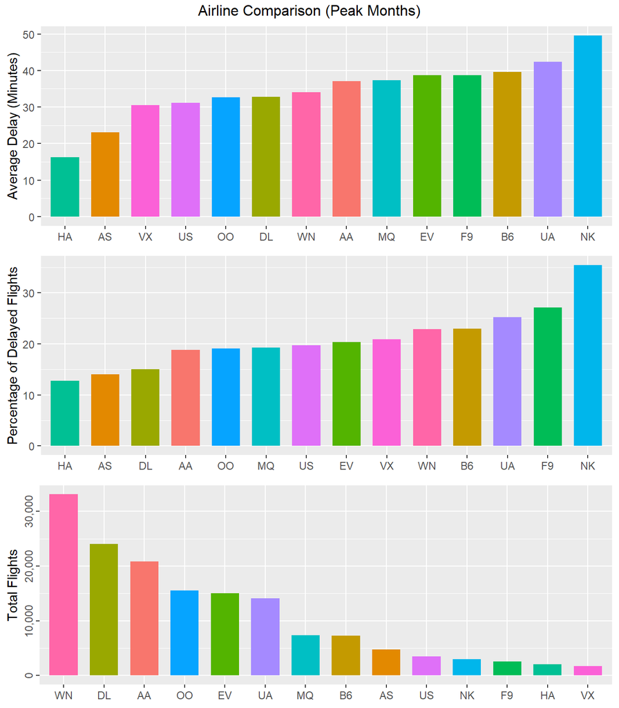

```r
grid.arrange(avrg_delay_plot_b,delay_perc_plot_b,total_flights_plot_b,top="Airline Comparison (Peak Months)")
```

### Chart 4, 5 and 6 visualised as a scatter plot during peak season

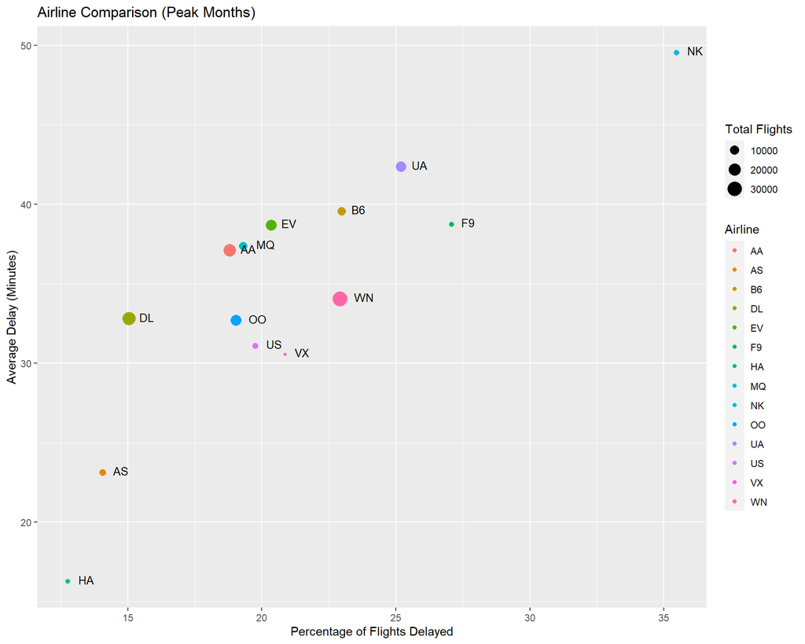

```r
airline_stats_b %>% ggplot(aes(x=delay_perc,y=avrg_delay,size=count)) +
  geom_point(aes(color=AIRLINE)) +
  geom_text(aes(label=AIRLINE,hjust=-0.7,vjust=0.3),size=3.5) +
  labs(title="Airline Comparison (Peak Months)",x="Percentage of Flights Delayed",y="Average Delay (Minutes)",size="Total Flights",color="Airline")
```

When we analyse the performance of the airlines during the busiest months of the year (Jun, Jul, Aug), we find that HA and AS still have the best performance. However, for the larger airlines, DL and OO are still able to main their performance in terms average delay and percentage of delayed flights. AA and WN’s performance, on the other hand, visibly deteriorates during the peak months.

### Which airport is best?

```r
avrg_airport_delay <- flights_cleaned %>%
  mutate(airport_delay_duration=ifelse(flights_cleaned$SECURITY_DELAY > 0,flights_cleaned$SECURITY_DELAY, ifelse(flights_cleaned$WEATHER_DELAY > 0,flights_cleaned$WEATHER_DELAY,NA))) %>%
  group_by(ORIGIN_AIRPORT) %>%
  filter(airport_delay_duration > 0) %>%
  summarise(avrg_airport_delay=mean(airport_delay_duration)) %>%
  arrange(desc(.[,2]))

airports_df <- flights_cleaned %>% group_by(ORIGIN_AIRPORT) %>% summarise(origin=n())

flights_cleaned$airport_delays <- 0
index <- (flights_cleaned$SECURITY_DELAY > 0 | flights_cleaned$WEATHER_DELAY > 0) & !is.na(flights_cleaned$SECURITY_DELAY)
flights_cleaned$airport_delays[index] <- flights_cleaned$airport_delays[index] + 1
airport_delays <- flights_cleaned %>% group_by(ORIGIN_AIRPORT) %>% summarise(airport_delays=sum(airport_delays))

taxi_out_time <- flights_cleaned %>% .[!is.na(flights_cleaned$TAXI_OUT),] %>% group_by(ORIGIN_AIRPORT) %>% summarise(avrg_taxi_out=mean(TAXI_OUT))
taxi_in_time <- flights_cleaned %>% .[!is.na(flights_cleaned$TAXI_IN),] %>% group_by(DESTINATION_AIRPORT) %>% summarise(avrg_taxi_in=mean(TAXI_IN))

merged2 <- merge(x=airports_df,y=airport_delays,by="ORIGIN_AIRPORT",all.x=T)
merged2 <- merge(merged2,taxi_out_time,by="ORIGIN_AIRPORT",all.x=T)
merged2 <- merge(x=merged2,y=taxi_in_time,by.x="ORIGIN_AIRPORT",by.y="DESTINATION_AIRPORT",all.x=T)
merged2 <- merge(x=merged2,y=avrg_airport_delay,by="ORIGIN_AIRPORT",all.x=T)
merged2[is.na(merged2$avrg_airport_delay),]$avrg_airport_delay <- 0
merged2$delay_perc <- (merged2$airport_delays/merged2$origin)*100

head(merged2,5)
```

```
##   ORIGIN_AIRPORT origin airport_delays avrg_taxi_out avrg_taxi_in
## 1          10135     29              0     11.655172     3.739130
## 2          10136     26              1      9.434783     4.523810
## 3          10140    185              3     10.967213     5.494118
## 4          10141     11              0     20.545455     4.500000
## 5          10146      5              0     15.400000     3.636364
##   avrg_airport_delay delay_perc
## 1                  0   0.000000
## 2                146   3.846154
## 3                 43   1.621622
## 4                  0   0.000000
## 5                  0   0.000000
```

### Delay % against Average Airport Delay

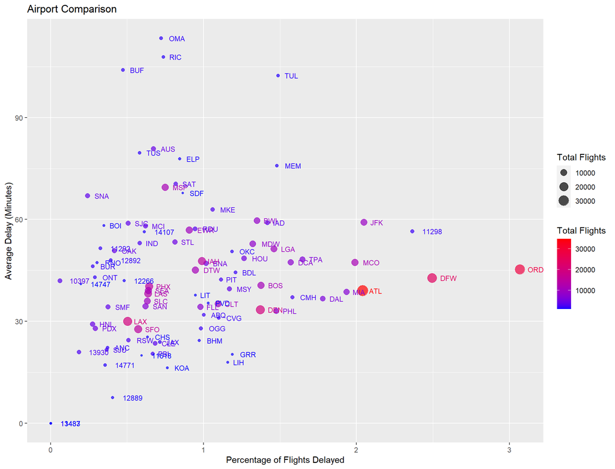

```r
merged2 %>% filter(origin>=1000) %>%
  ggplot(aes(x=delay_perc,y=avrg_airport_delay,color=origin,size=origin)) + geom_point(alpha=0.7) +
  labs(title="Airport Comparison",x="Percentage of Flights Delayed",y="Average Delay (Minutes)",color="Total Flights",size="Total Flights") +
  scale_color_gradient(low="blue", high="red") +
  geom_text(aes(label=ORIGIN_AIRPORT,hjust=-0.5,vjust=0.5),size=3)
```

For this visualisation, we filter out airports with fewer than 1000 total flights. Taking into account the total flights at each airport, LAX and SFO perform the best with the lowest average delay and lowest percentage of flights delayed.

### Average Taxi Out against Average Taxi In

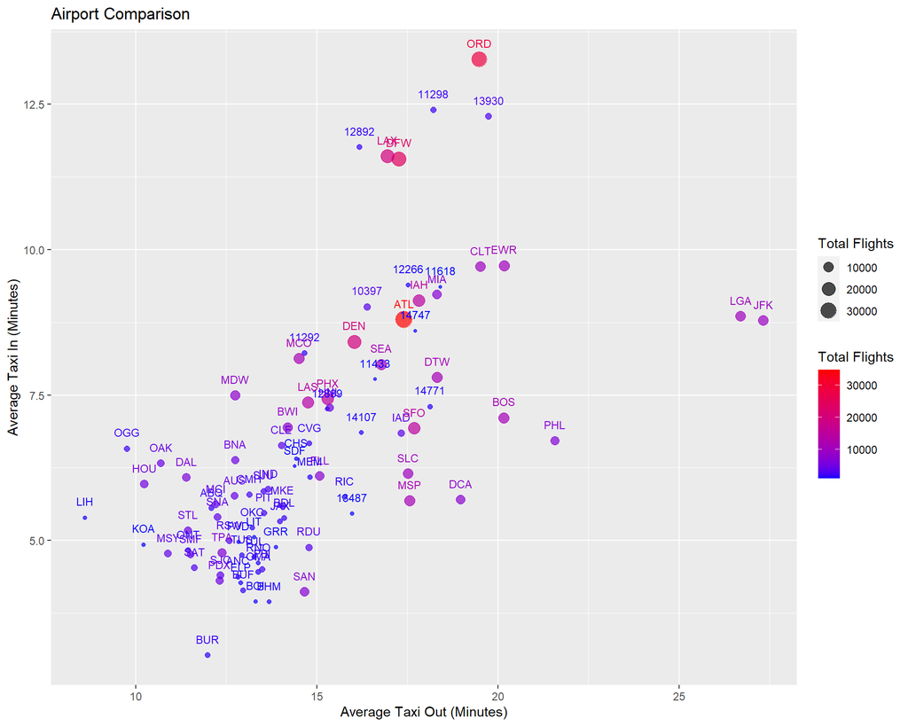

```r
merged2 %>% filter(origin>=1000) %>%
  ggplot(aes(x=avrg_taxi_out,y=avrg_taxi_in,color=origin,size=origin)) + geom_point(alpha=0.7) +
  labs(title="Airport Comparison",x="Average Taxi Out (Minutes)",y="Average Taxi In (Minutes)",color="Total Flights",size="Total Flights") +
  scale_color_gradient(low="blue", high="red") +
  geom_text(aes(label=ORIGIN_AIRPORT,hjust=0.5,vjust=-1.4),size=3)
```

Similarly, here, we also filter out airports with fewer than 1000 total flights. When it comes to average taxi in and out duration, LAX performs quite poorly compared to others, despite doing well in the terms of delays. Airports such as PHX, SFO and LAS have better average taxi in and out durations.

### Airport connectivity

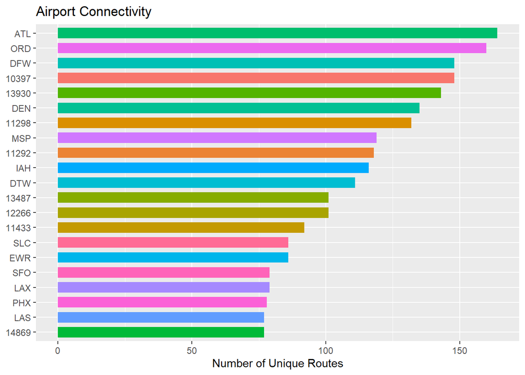

```r
flights_cleaned %>% group_by(ORIGIN_AIRPORT) %>%
  summarise(count = n_distinct(DESTINATION_AIRPORT)) %>%
  arrange(-count) %>%
  top_n(20) %>%
  ggplot(aes(x=reorder(ORIGIN_AIRPORT, count),y=count,fill=ORIGIN_AIRPORT)) +
  geom_bar(stat="identity",width=0.7) +
  labs(title="Airport Connectivity",y="Number of Unique Routes") +
  theme(axis.title.y=element_blank(),legend.position = "none") +
  coord_flip()
```

Airports are also measured by their connectivity, which is the number of connections an airport has to other airports. In this regard, ATL, ORD, DFW, 10397 and 13930 are the top 5.

### What is the seasonal effect on flight performance?

```r
num_flights <- flights_cleaned %>% mutate(month=month(date)) %>% group_by(month) %>% summarise(num_flights=n())

delay_types <- flights_cleaned %>% select(AIR_SYSTEM_DELAY,SECURITY_DELAY,AIRLINE_DELAY,LATE_AIRCRAFT_DELAY,WEATHER_DELAY,date)
delay_types <- delay_types[complete.cases(delay_types),]
delay_types <- delay_types %>% mutate(month=month(date)) %>%
  group_by(month) %>%
  summarise(AIR_SYSTEM_DELAYS=sum(AIR_SYSTEM_DELAY!=0),
            SECURITY_DELAYS=sum(SECURITY_DELAY!=0),
            AIRLINE_DELAYS=sum(AIRLINE_DELAY!=0),
            LATE_AIRCRAFT_DELAYS=sum(LATE_AIRCRAFT_DELAY!=0),
            WEATHER_DELAYS=sum(WEATHER_DELAY!=0)) %>%
  merge(num_flights,by="month") %>%
  mutate(AIR_SYSTEM_DELAYS_PERC=(AIR_SYSTEM_DELAYS/num_flights)*100,
         SECURITY_DELAYS_PERC=(SECURITY_DELAYS/num_flights)*100,
         AIRLINE_DELAYS_PERC=(AIRLINE_DELAYS/num_flights)*100,
         LATE_AIRCRAFT_DELAYS_PERC=(LATE_AIRCRAFT_DELAYS/num_flights)*100,
         WEATHER_DELAYS_PERC=(WEATHER_DELAYS/num_flights)*100)

head(delay_types,5)
```

```
##   month AIR_SYSTEM_DELAYS SECURITY_DELAYS AIRLINE_DELAYS LATE_AIRCRAFT_DELAYS
## 1     1              5554              27           5088                 5099
## 2     2              5552              27           5020                 5005
## 3     3              5157              29           5300                 5032
## 4     4              4441              13           4173                 4032
## 5     5              4714              30           4653                 4705
##   WEATHER_DELAYS num_flights AIR_SYSTEM_DELAYS_PERC SECURITY_DELAYS_PERC
## 1            597       46911              11.839441           0.05755580
## 2            885       42866              12.951990           0.06298698
## 3            474       50357              10.240880           0.05758882
## 4            494       48280               9.198426           0.02692626
## 5            624       49640               9.496374           0.06043513
##   AIRLINE_DELAYS_PERC LATE_AIRCRAFT_DELAYS_PERC WEATHER_DELAYS_PERC
## 1           10.846070                 10.869519           1.2726226
## 2           11.710913                 11.675920           2.0645733
## 3           10.524853                  9.992652           0.9412793
## 4            8.643331                  8.351284           1.0231980
## 5            9.373489                  9.478243           1.2570508
```

### Delay types across months

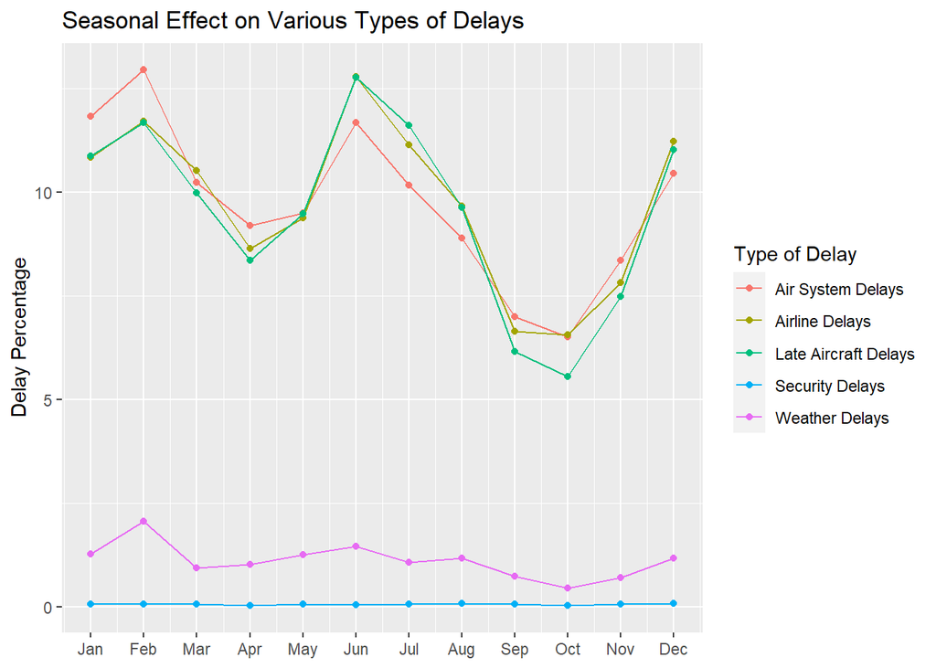

```r
delay_types %>% ggplot() +
  geom_line(aes(x=month,y=AIR_SYSTEM_DELAYS_PERC,color="Air System Delays")) + geom_point(aes(x=month,y=AIR_SYSTEM_DELAYS_PERC,color="Air System Delays")) +
  geom_line(aes(x=month,y=SECURITY_DELAYS_PERC,color="Security Delays")) + geom_point(aes(x=month,y=SECURITY_DELAYS_PERC,color="Security Delays")) +
  geom_line(aes(x=month,y=AIRLINE_DELAYS_PERC,color="Airline Delays")) + geom_point(aes(x=month,y=AIRLINE_DELAYS_PERC,color="Airline Delays")) +
  geom_line(aes(x=month,y=LATE_AIRCRAFT_DELAYS_PERC,color="Late Aircraft Delays")) + geom_point(aes(x=month,y=LATE_AIRCRAFT_DELAYS_PERC,color="Late Aircraft Delays")) +
  geom_line(aes(x=month,y=WEATHER_DELAYS_PERC,color="Weather Delays")) + geom_point(aes(x=month,y=WEATHER_DELAYS_PERC,color="Weather Delays")) +
  labs(title="Seasonal Effect on Various Types of Delays",y="Delay Percentage",colour="Type of Delay") +
  theme(axis.title.x=element_blank()) +
  scale_x_continuous(breaks=c(1,2,3,4,5,6,7,8,9,10,11,12),labels=c("Jan","Feb","Mar","Apr","May","Jun","Jul","Aug","Sep","Oct","Nov","Dec"))
```

From the visualisation, we can see that the periods with the greatest effects on delays are Jun-Jul and Dec-Feb. These periods experience the highest percentage of delays.

### Taxi In and Out across the year

```r
taxi_plot <- flights_cleaned %>% .[complete.cases(flights_cleaned$TAXI_OUT),] %>%
  .[complete.cases(.$TAXI_IN),] %>%
  mutate(month=month(date)) %>%
  group_by(month) %>%
  summarise(avrg_taxi_in=mean(TAXI_IN),avrg_taxi_out=mean(TAXI_OUT))
```

### Taxi In Plot

```r
taxi_in <- taxi_plot %>% ggplot() + geom_line(aes(x=month,y=avrg_taxi_in)) +
  geom_point(aes(x=month,y=avrg_taxi_in)) +
  labs(y="Average Taxi In (Minutes)") +
  theme(axis.title.x=element_blank()) +
  scale_x_continuous(breaks=c(1,2,3,4,5,6,7,8,9,10,11,12),labels=c("Jan","Feb","Mar","Apr","May","Jun","Jul","Aug","Sep","Oct","Nov","Dec"))
```

### Taxi Out Plot

```r
taxi_out <- taxi_plot %>% ggplot() + geom_line(aes(x=month,y=avrg_taxi_out)) +
  geom_point(aes(x=month,y=avrg_taxi_out)) +
  labs(y="Average Taxi Out (Minutes)") +
  theme(axis.title.x=element_blank()) +
  scale_x_continuous(breaks=c(1,2,3,4,5,6,7,8,9,10,11,12),labels=c("Jan","Feb","Mar","Apr","May","Jun","Jul","Aug","Sep","Oct","Nov","Dec"))
```

### Cancelled Flights

```r
cancelled_flights <- flights_cleaned %>% mutate(month=month(date)) %>%
  group_by(month) %>%
  summarise(cancelled_flights=sum(CANCELLED)) %>%
  ggplot() + geom_line(aes(x=month,y=cancelled_flights)) +
  geom_point(aes(x=month,y=cancelled_flights)) +
  labs(y="Cancelled Flights") +
  theme(axis.title.x=element_blank()) +
  scale_x_continuous(breaks=c(1,2,3,4,5,6,7,8,9,10,11,12),labels=c("Jan","Feb","Mar","Apr","May","Jun","Jul","Aug","Sep","Oct","Nov","Dec"))
```

### Combine Taxi In, Taxi Out and Cancelled Flights

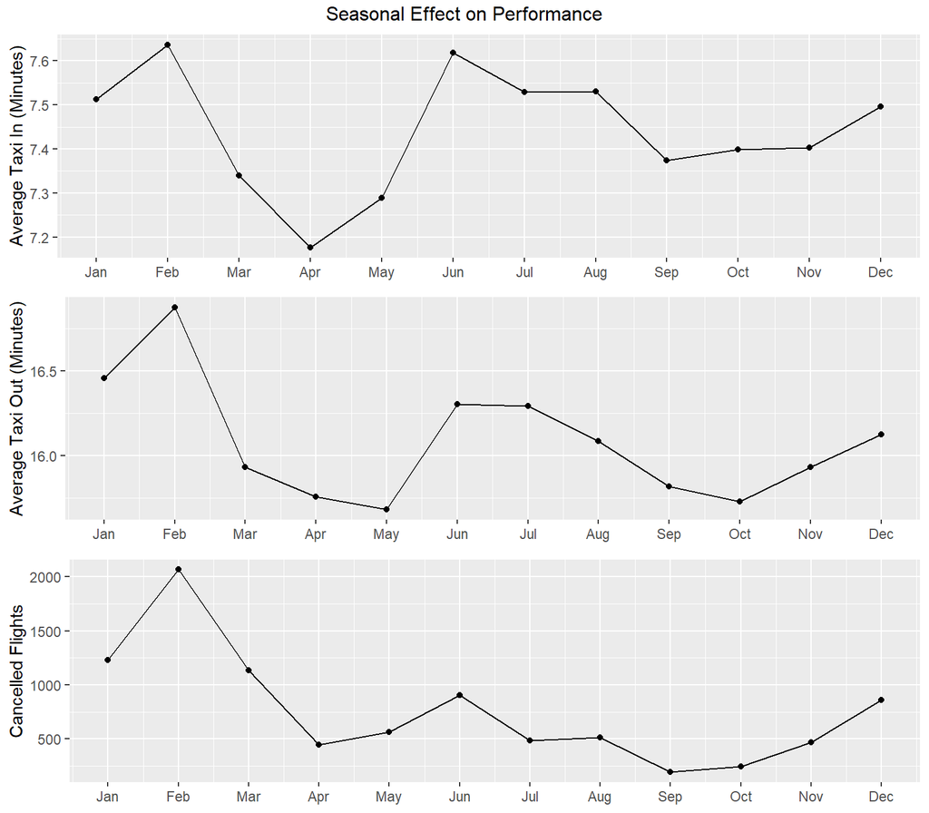

```r
grid.arrange(taxi_in,taxi_out,cancelled_flights,top="Seasonal Effect on Performance")
```

### Visualise data on a map

```r
ggmap::register_google(key = 'AIzaSyDRyVUxMAnQuuKaqzXI2j4F9US535l4TmI')

connectivity <- flights_cleaned %>% group_by(ORIGIN_AIRPORT) %>%
  summarise(unique_routes = n_distinct(DESTINATION_AIRPORT))

airports_cleaned <- airports[complete.cases(airports),]
airport_connectivity <- merge(x=airports_cleaned,y=connectivity,by.x="IATA_CODE",by.y="ORIGIN_AIRPORT")

airport_connectivity %>% arrange(desc(unique_routes)) %>%
  select(IATA_CODE,AIRPORT,LATITUDE,LONGITUDE,unique_routes) %>%
  top_n(10)
```

```
##    IATA_CODE                                          AIRPORT LATITUDE
## 1        ATL Hartsfield-Jackson Atlanta International Airport 33.64044
## 2        ORD             Chicago O'Hare International Airport 41.97960
## 3        DFW          Dallas/Fort Worth International Airport 32.89595
## 4        DEN                     Denver International Airport 39.85841
## 5        MSP     Minneapolis-Saint Paul International Airport 44.88055
## 6        IAH             George Bush Intercontinental Airport 29.98047
## 7        DTW                     Detroit Metropolitan Airport 42.21206
## 8        EWR             Newark Liberty International Airport 40.69250
## 9        SLC             Salt Lake City International Airport 40.78839
## 10       LAX                Los Angeles International Airport 33.94254
## 11       SFO              San Francisco International Airport 37.61900
##     LONGITUDE unique_routes
## 1   -84.42694           164
## 2   -87.90446           160
## 3   -97.03720           148
## 4  -104.66700           135
## 5   -93.21692           119
## 6   -95.33972           116
## 7   -83.34884           111
## 8   -74.16866            86
## 9  -111.97777            86
## 10 -118.40807            79
## 11 -122.37484            79
```

```r
loc <-c(lon=-123,lat=50)

map1 <- get_map(location=loc,zoom=2,source="google",maptype="roadmap")
m1 <- ggmap(map1, base_layer = ggplot(data=airport_connectivity,aes(x=LONGITUDE,y=LATITUDE,color=unique_routes)))
```

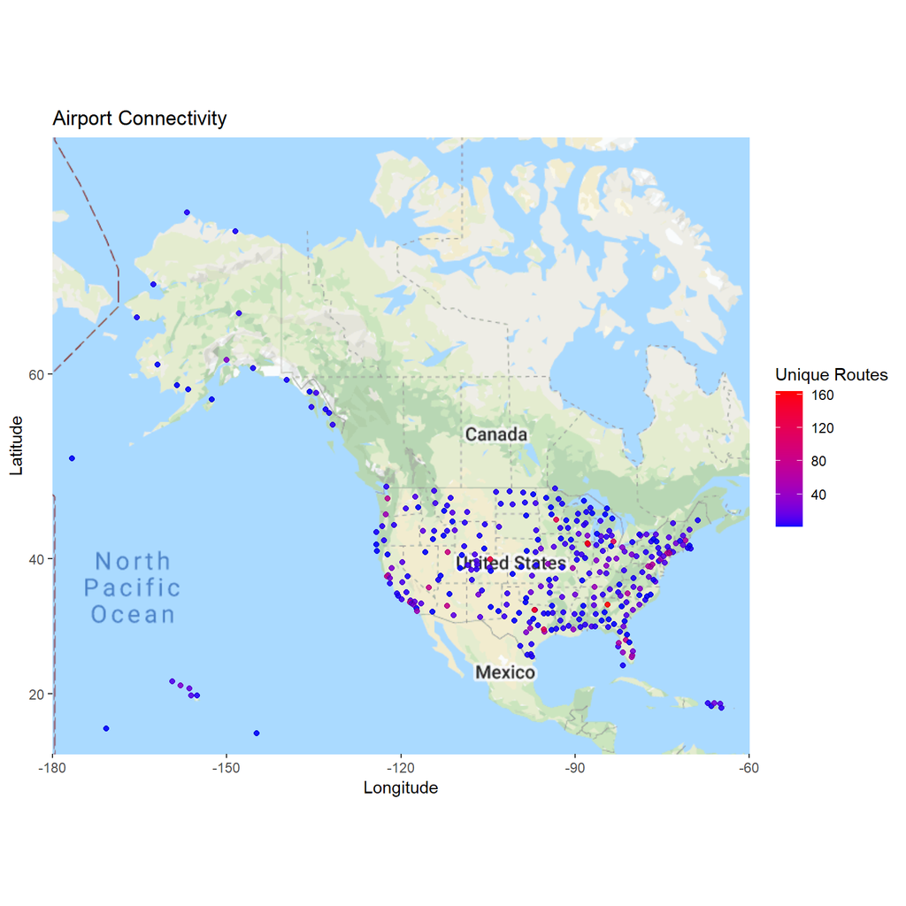

```r
# Map of Airport Connectivity
m1 + geom_point(alpha=0.9,size=1.5) +
  geom_point(shape = 1,size = 1.5,colour = "black",alpha=0.2) +
  labs(title="Airport Connectivity",x="Longitude",y="Latitude",color="Unique Routes") +
  scale_x_continuous(limits = c(-180, -60), expand = c(0, 0)) +
  scale_y_continuous(limits = c(10, 75), expand = c(0, 0)) +
  scale_color_gradient(low="blue", high="red")
```

This visualisation shows the airports with the best connectivity.

### Regions that experience the most weather delays

```r
weather_delay <- flights_cleaned %>% filter(WEATHER_DELAY>0) %>%
  select(ORIGIN_AIRPORT,WEATHER_DELAY) %>%
  merge(x=.,y=airports,by.x="ORIGIN_AIRPORT",by.y="IATA_CODE") %>%
  .[complete.cases(.),]

leaflet(weather_delay) %>% addProviderTiles(providers$CartoDB.DarkMatter) %>%
  addWebGLHeatmap(lng=~LONGITUDE, lat=~LATITUDE, size = 200000)
```

[interactive chart not shown]

This visualisation shows the regions which experience the most weather delays. From the map, we can see that weather delays occur most frequently in airports found near the coastline. However, there are more airports located near the coastlines and thus, the high density of weather delays in these regions could also be attributed to this.